# Lab 8: Cannabis Types

Author

Maile Yamasaki

Github Link: https://github.com/maileyamasaki/Week_9

```python
import pandas as pd
import numpy as np
from sklearn.pipeline import Pipeline
from sklearn.preprocessing import StandardScaler, LabelEncoder
from sklearn.compose import make_column_selector, ColumnTransformer
from sklearn.model_selection import cross_val_score
from sklearn.metrics import confusion_matrix
from sklearn.model_selection import GridSearchCV, train_test_split
from sklearn.svm import SVC
from sklearn.discriminant_analysis import LinearDiscriminantAnalysis, QuadraticDiscriminantAnalysis
from sklearn.tree import DecisionTreeClassifier, plot_tree
from sklearn.neighbors import KNeighborsClassifier
from sklearn.linear_model import LogisticRegression
```

```python
data = pd.read_csv("https://www.dropbox.com/s/s2a1uoiegitupjc/cannabis_full.csv?dl=1")
data = data.dropna()
```

**Part 1: Binary Classification**

```python
dat = data[data["Type"].isin(["sativa", "indica"])]
```

I will use ROC AUC because it measures how well the model separates the two classes overall, without favoring either Indica or Sativa.

```python
X = dat.drop(['Type', 'Strain', 'Effects', 'Flavor'], axis=1)
y = dat['Type']
```

```python
ct = ColumnTransformer(
  [
    ("standardize", StandardScaler(), make_column_selector(dtype_include=np.number))
  ],
  remainder = "passthrough"
).set_output(transform = "pandas")
```

**Q1: LDA**

```python
lda = Pipeline([
    ("preprocessing", ct),
    ("lda", LinearDiscriminantAnalysis())
]).set_output(transform="pandas")

lda_roc_auc = cross_val_score(lda, X, y, cv=5, scoring='roc_auc')

print("Mean ROC AUC:", lda_roc_auc.mean())

lda_fit = lda.fit(X,y)

y_pred_lda = pd.Series(lda_fit.predict(X), name = "Predicted")

print(pd.crosstab(y, y_pred_lda, margins=True))
```

```
Mean ROC AUC: 0.9339243002718665
Predicted  indica  sativa  All
Type
indica        194     121  315
sativa        113      42  155
All           307     163  470
```

**Q2: QDA**

```python
qda = Pipeline([
    ("preprocessing", ct),
    ("qda", QuadraticDiscriminantAnalysis())
]).set_output(transform="pandas")

param_grid_qda = {"qda__reg_param": [0.0, 0.1, 0.2, 0.5, 0.9]}

qda_grid = GridSearchCV(qda, param_grid_qda, cv=5, scoring="roc_auc")

qda_fit = qda_grid.fit(X, y)

print("Mean ROC AUC:", qda_grid.best_score_)

y_pred_qda = pd.Series(qda_fit.predict(X), name="Predicted")

print(pd.crosstab(y, y_pred_qda, margins=True))
```

```
Mean ROC AUC: 0.8874344530000418
Predicted  indica  sativa  All
Type
indica        184     131  315
sativa        104      51  155
All           288     182  470
```

**Q3: SVC**

```python
svc = Pipeline([
    ("preprocessing", ct),
    ("svc", SVC(kernel="linear"))
]).set_output(transform="pandas")

param_grid_svc = {"svc__C": [0.01, 0.1, 1, 10, 100]}

svc_grid = GridSearchCV(svc, param_grid_svc, cv=5, scoring="roc_auc")

svc_fit = svc_grid.fit(X, y)

print("Mean ROC AUC:", svc_grid.best_score_)

y_pred_svc = pd.Series(svc_fit.predict(X), name="Predicted")

print(pd.crosstab(y, y_pred_svc, margins=True))
```

```
Mean ROC AUC: 0.9360083645365715
Predicted  indica  sativa  All
Type
indica        194     121  315
sativa        114      41  155
All           308     162  470
```

**Q4: SVM**

```python
svm = Pipeline([
    ("preprocessing", ct),
    ("svm", SVC(kernel="poly"))
]).set_output(transform="pandas")

param_grid_svm = {
    "svm__C": [0.01, 0.1, 1, 10, 100],
    "svm__degree": [2, 3, 4],
    "svm__coef0": [0, 1]
}

svm_grid = GridSearchCV(svm, param_grid_svm, cv=5, scoring="roc_auc")

svm_fit = svm_grid.fit(X, y)

print("Mean ROC AUC:", svm_grid.best_score_)

y_pred_svm = pd.Series(svm_fit.predict(X), name="Predicted")

print(pd.crosstab(y, y_pred_svm, margins=True))
```

```
Mean ROC AUC: 0.9335824141969283
Predicted  indica  sativa  All
Type
indica        202     113  315
sativa        113      42  155
All           315     155  470
```

**Part 2: Natural Multiclass**

**Q1**

```
Mean Accuracy: 0.6198084064030954
Predicted  hybrid  indica  sativa   All
Type
hybrid        594     307     151  1052
indica        358     166      86   610
sativa        217     109      55   381
All          1169     582     292  2043
```

[output not shown]

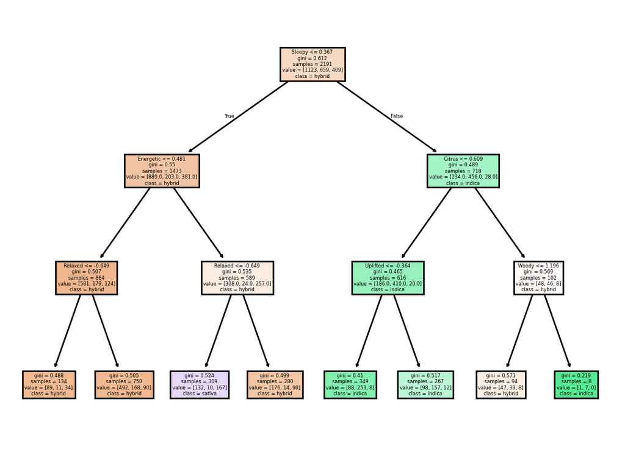

```python
X = data.drop(['Type', 'Strain', 'Effects', 'Flavor'], axis=1)
y = data["Type"]

dt = Pipeline([
    ("preprocessing", ct),
    ("dt_classifier", DecisionTreeClassifier(max_depth=3, random_state=42))]
).set_output(transform="pandas")

param_grid_dt = {"dt_classifier__ccp_alpha": [0.0, 0.001, 0.01, 0.1]}

dt_grid = GridSearchCV(dt, param_grid_dt, cv=5, scoring="accuracy")

dt_fit = dt_grid.fit(X, y)

print("Mean Accuracy:", dt_grid.best_score_)

y_pred_dt = pd.Series(dt_fit.predict(X), name="Predicted")

print(pd.crosstab(y, y_pred_dt, margins=True))

plot_tree(
    dt_fit.best_estimator_.named_steps["dt_classifier"],
    feature_names = X.columns,
    class_names = dt_fit.best_estimator_.named_steps["dt_classifier"].classes_,
    filled = True
)
```

The decision tree uses strain effects to distinguish between Hybrid, Indica, and Sativa. The first split is based on the “Sleepy” effect. Later splits include “Energetic,” “Relaxed,” and “Uplifted,” which further adjust the classification. Overall accuracy is best on Hybrid strains which makes sense because many strains overlap in effects and hybrids share traits with both Indica and Sativa.

**Q2**

**LDA**

```python
lda = Pipeline([
    ("preprocessing", ct),
    ("lda", LinearDiscriminantAnalysis())
]).set_output(transform="pandas")

lda_accuracy = cross_val_score(lda, X, y, cv=5, scoring='accuracy')

print("Mean Accuracy:", lda_accuracy.mean())

lda_fit = lda.fit(X,y)

y_pred_lda = pd.Series(lda_fit.predict(X), name = "Predicted")

print(pd.crosstab(y, y_pred_lda, margins=True))
```

```
Mean Accuracy: 0.6280244640683995
Predicted  hybrid  indica  sativa   All
Type
hybrid        547     337     168  1052
indica        339     181      90   610
sativa        200     122      59   381
All          1086     640     317  2043
```

**QDA**

```python
qda = Pipeline([
    ("preprocessing", ct),
    ("qda", QuadraticDiscriminantAnalysis())
]).set_output(transform="pandas")

param_grid_qda = {"qda__reg_param": [0.0, 0.1, 0.2, 0.5, 0.9]}

qda_grid = GridSearchCV(qda, param_grid_qda, cv=5, scoring="accuracy")

qda_fit = qda_grid.fit(X, y)

print("Mean Accuracy:", qda_grid.best_score_)

y_pred_qda = pd.Series(qda_fit.predict(X), name="Predicted")

print(pd.crosstab(y, y_pred_qda, margins=True))
```

```
Mean Accuracy: 0.5728305301588292
Predicted  hybrid  indica  sativa   All
Type
hybrid        463     342     247  1052
indica        278     192     140   610
sativa        162     131      88   381
All           903     665     475  2043
```

**KNN**

```python
knn = Pipeline([
    ("preprocessing", ct),
    ("knn", KNeighborsClassifier())
]).set_output(transform="pandas")

param_grid_knn = {"knn__n_neighbors": [1, 2, 7, 10, 20]}

knn_grid = GridSearchCV(knn, param_grid_knn, cv=5, scoring="accuracy")

knn_fit = knn_grid.fit(X, y)

print("Mean Accuracy:", knn_grid.best_score_)

y_pred_knn = pd.Series(knn_fit.predict(X), name="Predicted")

print(pd.crosstab(y, y_pred_knn, margins=True))
```

```
Mean Accuracy: 0.5645988704090866
Predicted  hybrid  indica  sativa   All
Type
hybrid        743     261      48  1052
indica        441     136      33   610
sativa        271      87      23   381
All          1455     484     104  2043
```

**Q3**

The metric scores are worse, although the number of accurate predictions are higher. This could be explained by the fact that there in another strain: Hybrid. Thus it is more difficult to accurately predict the strain when there are more classes and there is more overlap between Sativa and Hybrid and Indica and Hybrid.

**Part 3: Multiclass from Binary**

**Q1**

**SVC - Indica vs. Not Indica**

```python
y_indica = (data["Type"] == "indica").astype(int)

svc_indica = Pipeline([
    ("preprocessing", ct),
    ("svc", SVC(kernel="linear"))
]).set_output(transform="pandas")

svc_indica_score = cross_val_score(svc_indica, X, y_indica, cv=5, scoring="accuracy")
print("SVC – Indica vs Not Indica Accuracy:", svc_indica_score.mean())

svc_indica_fit = svc_indica.fit(X, y_indica)
y_pred_indica = svc_indica_fit.predict(X)

print(pd.crosstab(y_indica, y_pred_indica, margins=True))
```

```
SVC – Indica vs Not Indica Accuracy: 0.7891461499256301
col_0     0    1   All
Type
0      1278  254  1532
1       203  456   659
All    1481  710  2191
```

**SVC - Sativa vs. Not Sativa**

```python
y_sativa = (data["Type"] == "sativa").astype(int)

svc_sativa = Pipeline([
    ("preprocessing", ct),
    ("svc", SVC(kernel="linear"))
]).set_output(transform="pandas")

svc_sativa_score = cross_val_score(svc_sativa, X, y_sativa, cv=5, scoring="accuracy")
print("SVC – Sativa vs Not Sativa Accuracy:", svc_sativa_score.mean())

svc_sativa_fit = svc_sativa.fit(X, y_sativa)
y_pred_sativa = svc_sativa_fit.predict(X)

print(pd.crosstab(y_sativa, y_pred_sativa, margins=True))
```

```
SVC – Sativa vs Not Sativa Accuracy: 0.8215443983316171
col_0     0  1   All
Type
0      1778  4  1782
1       404  5   409
All    2182  9  2191
```

**SVC - Hybrid vs. Not Hybrid**

```python
y_hybrid = (data["Type"] == "hybrid").astype(int)

svc_hybrid = Pipeline([
    ("preprocessing", ct),
    ("svc", SVC(kernel="linear"))
]).set_output(transform="pandas")

svc_hybrid_score = cross_val_score(svc_hybrid, X, y_hybrid, cv=5, scoring="accuracy")
print("SVC – Hybrid vs Not Hybrid Accuracy:", svc_hybrid_score.mean())

svc_hybrid_fit = svc_hybrid.fit(X, y_hybrid)
y_pred_hybrid = svc_hybrid_fit.predict(X)

print(pd.crosstab(y_hybrid, y_pred_hybrid, margins=True))
```

```
SVC – Hybrid vs Not Hybrid Accuracy: 0.6202587865738863
col_0    0     1   All
Type
0      513   555  1068
1      248   875  1123
All    761  1430  2191
```

**Logistic Regression - Indica vs. Not Indica**

```python
log_indica = Pipeline([
    ("preprocessing", ct),
    ("log", LogisticRegression(solver="liblinear"))
]).set_output(transform="pandas")

log_indica_score = cross_val_score(log_indica, X, y_indica, cv=5, scoring="accuracy")
print("LogReg – Indica vs Not Indica Accuracy:", log_indica_score.mean())

log_indica_fit = log_indica.fit(X, y_indica)
y_pred_log_indica = log_indica_fit.predict(X)

print(pd.crosstab(y_indica, y_pred_log_indica, margins=True))
```

```
LogReg – Indica vs Not Indica Accuracy: 0.7877762869119314
col_0     0    1   All
Type
0      1350  182  1532
1       232  427   659
All    1582  609  2191
```

**Logistic Regression - Sativa vs. Not Sativa**

```python
log_sativa = Pipeline([
    ("preprocessing", ct),
    ("log", LogisticRegression(solver="liblinear"))
]).set_output(transform="pandas")

log_sativa_score = cross_val_score(log_sativa, X, y_sativa, cv=5, scoring="accuracy")
print("LogReg – Sativa vs Not Sativa Accuracy:", log_sativa_score.mean())

log_sativa_fit = log_sativa.fit(X, y_sativa)
y_pred_log_sativa = log_sativa_fit.predict(X)

print(pd.crosstab(y_sativa, y_pred_log_sativa, margins=True))
```

```
LogReg – Sativa vs Not Sativa Accuracy: 0.823368802071957
col_0     0    1   All
Type
0      1689   93  1782
1       262  147   409
All    1951  240  2191
```

**Logistic Regression - Hybrid vs. Not Hybrid**

```python
log_hybrid = Pipeline([
    ("preprocessing", ct),
    ("log", LogisticRegression(solver="liblinear"))
]).set_output(transform="pandas")

log_hybrid_score = cross_val_score(log_hybrid, X, y_hybrid, cv=5, scoring="accuracy")
print("LogReg – Hybrid vs Not Hybrid Accuracy:", log_hybrid_score.mean())

log_hybrid_fit = log_hybrid.fit(X, y_hybrid)
y_pred_log_hybrid = log_hybrid_fit.predict(X)

print(pd.crosstab(y_hybrid, y_pred_log_hybrid, margins=True))
```

```
LogReg – Hybrid vs Not Hybrid Accuracy: 0.6156967370840745
col_0    0     1   All
Type
0      645   423  1068
1      336   787  1123
All    981  1210  2191
```

**Q2**

The best of the six models was the logistic regression model testing Sativa vs. Not Sativa and the worst of the models was the logstic regression model testing Hybrid vs. Not Hybrid. This makes intuitive sense because Sativa has the most distinct and recognizable effects. It also makes sense that Hybrid did the worst because there is more crossover among Hybrid strains and non Hybrid strains due to the fact that Hybrids are a mix of both Indica and Sativa.

**Q3**

**SVC - Indica vs. Sativa**

```python
dat_is = data[data["Type"].isin(["indica", "sativa"])]

X_is = dat_is.drop(['Type', 'Strain', 'Effects', 'Flavor'], axis=1)
y_is = dat_is["Type"]

svc_is = Pipeline([
    ("preprocessing", ct),
    ("svc", SVC(kernel="linear"))
]).set_output(transform="pandas")

svc_is_acc = cross_val_score(svc_is, X_is, y_is, cv=5, scoring="accuracy")
print("SVC Accuracy (Indica vs Sativa):", svc_is_acc.mean())

svc_is_fit = svc_is.fit(X_is, y_is)
y_pred_is = pd.Series(svc_is_fit.predict(X_is), name="Predicted")

print(pd.crosstab(y_is, y_pred_is, margins=True))
```

```
SVC Accuracy (Indica vs Sativa): 0.8576806634197711
Predicted  indica  sativa  All
Type
indica        190     125  315
sativa        111      44  155
All           301     169  470
```

**SVC - Indica vs. Hybrid**

```python
dat_ih = data[data["Type"].isin(["indica", "hybrid"])]

X_ih = dat_ih.drop(['Type', 'Strain', 'Effects', 'Flavor'], axis=1)
y_ih = dat_ih["Type"]

svc_ih = Pipeline([
    ("preprocessing", ct),
    ("svc", SVC(kernel="linear"))
]).set_output(transform="pandas")

svc_ih_acc = cross_val_score(svc_ih, X_ih, y_ih, cv=5, scoring="accuracy")
print("SVC Accuracy (Indica vs Hybrid):", svc_ih_acc.mean())

svc_ih_fit = svc_ih.fit(X_ih, y_ih)
y_pred_ih = pd.Series(svc_ih_fit.predict(X_ih), name="Predicted")

print(pd.crosstab(y_ih, y_pred_ih, margins=True))
```

```
SVC Accuracy (Indica vs Hybrid): 0.7575834828313347
Predicted  hybrid  indica   All
Type
hybrid        519     338   857
indica        320     200   520
All           839     538  1377
```

**SVC - Hybrid vs. Sativa**

```python
dat_hs = data[data["Type"].isin(["sativa", "hybrid"])]

X_hs = dat_hs.drop(['Type', 'Strain', 'Effects', 'Flavor'], axis=1)
y_hs = dat_hs["Type"]

svc_hs = Pipeline([
    ("preprocessing", ct),
    ("svc", SVC(kernel="linear"))
]).set_output(transform="pandas")

svc_hs_acc = cross_val_score(svc_hs, X_hs, y_hs, cv=5, scoring="accuracy")
print("SVC Accuracy (Hybrid vs Sativa):", svc_hs_acc.mean())

svc_hs_fit = svc_hs.fit(X_hs, y_hs)
y_pred_hs = pd.Series(svc_hs_fit.predict(X_hs), name="Predicted")

print(pd.crosstab(y_hs, y_pred_hs, margins=True))
```

```
SVC Accuracy (Hybrid vs Sativa): 0.7440952928402631
Predicted  hybrid  sativa   All
Type
hybrid        662      95   757
sativa        217      32   249
All           879     127  1006
```

**Logistic Regression - Indica vs. Sativa**

```python
dat_is = data[data["Type"].isin(["indica", "sativa"])]

X_is = dat_is.drop(['Type', 'Strain', 'Effects', 'Flavor'], axis=1)
y_is = dat_is["Type"]

log_is = Pipeline([
    ("preprocessing", ct),
    ("log", LogisticRegression(solver="liblinear"))
]).set_output(transform="pandas")

log_is_acc = cross_val_score(log_is, X_is, y_is, cv=5, scoring="accuracy")
print("LogReg Accuracy (Indica vs Sativa):", log_is_acc.mean())

log_is_fit = log_is.fit(X_is, y_is)
y_pred_log_is = pd.Series(log_is_fit.predict(X_is), name="Predicted")

print(pd.crosstab(y_is, y_pred_log_is, margins=True))
```

```
LogReg Accuracy (Indica vs Sativa): 0.8511298319512088
Predicted  indica  sativa  All
Type
indica        188     127  315
sativa        109      46  155
All           297     173  470
```

**Logistic Regression - Indica vs. Hybrid**

```python
dat_ih = data[data["Type"].isin(["indica", "hybrid"])]

X_ih = dat_ih.drop(['Type', 'Strain', 'Effects', 'Flavor'], axis=1)
y_ih = dat_ih["Type"]

log_ih = Pipeline([
    ("preprocessing", ct),
    ("log", LogisticRegression(solver="liblinear"))
]).set_output(transform="pandas")

log_ih_acc = cross_val_score(log_ih, X_ih, y_ih, cv=5, scoring="accuracy")
print("LogReg Accuracy (Indica vs Hybrid):", log_ih_acc.mean())

log_ih_fit = log_ih.fit(X_ih, y_ih)
y_pred_log_ih = pd.Series(log_ih_fit.predict(X_ih), name="Predicted")

print(pd.crosstab(y_ih, y_pred_log_ih, margins=True))
```

```
LogReg Accuracy (Indica vs Hybrid): 0.7463538224278475
Predicted  hybrid  indica   All
Type
hybrid        559     298   857
indica        328     192   520
All           887     490  1377
```

**Logistic Regression - Hybrid vs. Sativa**

```python
dat_hs = data[data["Type"].isin(["sativa", "hybrid"])]

X_hs = dat_hs.drop(['Type', 'Strain', 'Effects', 'Flavor'], axis=1)
y_hs = dat_hs["Type"]

log_hs = Pipeline([
    ("preprocessing", ct),
    ("log", LogisticRegression(solver="liblinear"))
]).set_output(transform="pandas")

log_hs_acc = cross_val_score(log_hs, X_hs, y_hs, cv=5, scoring="accuracy")
print("LogReg Accuracy (Hybrid vs Sativa):", log_hs_acc.mean())

log_hs_fit = log_hs.fit(X_hs, y_hs)
y_pred_log_hs = pd.Series(svc_hs_fit.predict(X_hs), name="Predicted")

print(pd.crosstab(y_hs, y_pred_log_hs, margins=True))
```

```
LogReg Accuracy (Hybrid vs Sativa): 0.7434566008813949
Predicted  hybrid  sativa   All
Type
hybrid        662      95   757
sativa        217      32   249
All           879     127  1006
```

**Q4**

The best of the six models was the SVC model testing Indica vs. Sativa and the worst of the models was the logistic regression model testing Hybrid vs. Sativa. This makes intuitive sense because Sativa and Indica vary the most from eachother making them more distinguishable. It also makes sense that Hybrid vs. Sativa did the worst because there is more crossover among Hybrid strains and Sativa strains in this data set making it harder to distinguish the two.

**Q5**

If we had simply input the full data, with three classes, into the LogisticRegression function, it would taken an “OvR” approach as the default because it naturally models one class versus all others using separate logistic functions. For the SVC function, it would have taken the “OvO” approach because SVMs work best when comparing classes two at a time.